# LGBTQI+ Hate Crime Analysis — 02: Exploratory Data Analysis

Guilherme Arpi

2026-09-29

## Overview

This notebook produces 10 publication-quality exploratory charts from the pipeline outputs, covering temporal trends, subgroup breakdown, geographic distribution, inequality relationships, and seasonality. All charts are also saved to `charts/` as 150 dpi PNG files.

**Normalisation strategy**

Two rate denominators are used throughout:

- **Track 1 — `RATE_PER_100K_TOTAL`**: incidents per 100k total population. Available for all years 1991–2024.
- **Track 2 — `RATE_PER_100K_LGBT`**: incidents per 100k LGBT adult residents. Available 2012–2024 only. Pre-2012 self-identification data does not exist at the state level; backward interpolation was deliberately avoided to prevent corrupting trend analysis.

## Setup

```r
library(tidyverse)
library(scales)
library(patchwork)
library(RColorBrewer)
```

```r
BASE_DIR   <- getwd()
DATA_DIR   <- file.path(BASE_DIR, "data")
CHARTS_DIR <- file.path(BASE_DIR, "charts")
dir.create(CHARTS_DIR, showWarnings = FALSE, recursive = TRUE)

BIAS_COLORS <- c(
  "Anti-Gay (Male)"             = "#2196F3",
  "Anti-Lesbian"                = "#E91E63",
  "Anti-LGBTQ (General)"        = "#9C27B0",
  "Anti-Transgender"            = "#FF9800",
  "Anti-Bisexual"               = "#4CAF50",
  "Anti-Gender Non-Conforming"  = "#795548"
)
REGION_COLORS <- c(
  "West" = "#1565C0", "Northeast" = "#C62828",
  "South" = "#2E7D32", "Midwest" = "#F57F17"
)
LAW_COLORS <- c(
  "No Law"             = "#B71C1C",
  "Sexual Orientation" = "#EF9A9A",
  "Full Protection"    = "#1B5E20"
)

theme_hate <- function() {
  theme_minimal(base_size = 11) +
    theme(
      plot.title       = element_text(face = "bold", size = 13, colour = "#1A1A1A"),
      plot.subtitle    = element_text(size = 10, colour = "#555555"),
      axis.text        = element_text(colour = "#444444"),
      axis.title       = element_text(size = 10, colour = "#444444"),
      panel.grid.minor = element_blank(),
      panel.grid.major = element_line(colour = "#EEEEEE"),
      legend.text      = element_text(size = 9),
      legend.title     = element_text(size = 9, face = "bold"),
      plot.background  = element_rect(fill = "white", colour = NA),
      panel.background = element_rect(fill = "#FAFAFA", colour = NA)
    )
}

save_chart <- function(plot, filename, width = 10, height = 5) {
  ggsave(file.path(CHARTS_DIR, filename), plot = plot,
         width = width, height = height, dpi = 150, bg = "white")
}
```

```r
full <- read_csv(file.path(DATA_DIR, "lgbtq_hate_crimes_full.csv"),
                 show_col_types = FALSE)

sy <- read_csv(file.path(DATA_DIR, "state_year_aggregate.csv"),
               show_col_types = FALSE)

# Time-varying law lookup — one row per state × year
law_lookup <- tryCatch(
  read_csv(file.path(DATA_DIR, "state_law_panel.csv"), show_col_types = FALSE) |>
    rename(STATE_NAME = State, DATA_YEAR = Year) |>
    select(STATE_NAME, DATA_YEAR, LAW_LEVEL, HC_LAW_SO, HC_LAW_GI),
  error = function(e) {
    message("state_law_panel.csv not found — law-level chart will be skipped.")
    NULL
  }
)

cat(sprintf("Full dataset: %s rows (%d–%d)\nState-year:   %s rows\n",
            format(nrow(full), big.mark=","),
            min(full$YEAR, na.rm=TRUE), max(full$YEAR, na.rm=TRUE),
            format(nrow(sy), big.mark=",")))
```

```
## Full dataset: 45,318 rows (1991–2024)
## State-year:   1,543 rows
```

## Chart 01 — Annual Incident Trend (1991–2024)

The long-run trend line shows a statistically significant upward trend (Mann-Kendall, p < 0.001, Sen’s slope ≈ +27 incidents/year). Key political and social events are annotated as reference points. Note the sharp acceleration after 2019.

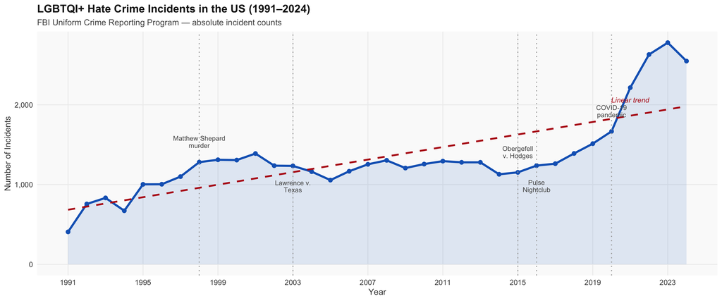

```r
yearly    <- full |> count(YEAR, name = "INCIDENTS")
trend_mod <- lm(INCIDENTS ~ YEAR, data = yearly)
yearly    <- yearly |> mutate(TREND = predict(trend_mod))

events <- tibble(
  YEAR  = c(1998, 2003, 2015, 2016, 2020),
  LABEL = c("Matthew Shepard\nmurder", "Lawrence v.\nTexas",
            "Obergefell\nv. Hodges", "Pulse\nNightclub", "COVID-19\npandemic"),
  VJUST = c(-1.2, 2.2, -1.2, 2.2, -1.2)
) |> left_join(yearly, by = "YEAR")

p01 <- ggplot(yearly, aes(x = YEAR, y = INCIDENTS)) +
  geom_area(alpha = 0.12, fill = "#1565C0") +
  geom_line(colour = "#1565C0", linewidth = 1.2) +
  geom_point(colour = "#1565C0", size = 2) +
  geom_line(aes(y = TREND), colour = "#B71C1C", linewidth = 1, linetype = "dashed") +
  geom_vline(data = events, aes(xintercept = YEAR),
             colour = "#AAAAAA", linewidth = 0.6, linetype = "dotted") +
  geom_text(data = events, aes(label = LABEL, vjust = VJUST),
            size = 2.8, colour = "#555555", lineheight = 0.9) +
  annotate("text", x = 2021, y = max(yearly$TREND) + 80,
           label = "Linear trend", colour = "#B71C1C", size = 3, fontface = "italic") +
  scale_x_continuous(breaks = seq(1991, 2024, 4)) +
  scale_y_continuous(labels = comma) +
  labs(title    = "LGBTQI+ Hate Crime Incidents in the US (1991–2024)",
       subtitle = "FBI Uniform Crime Reporting Program — absolute incident counts",
       x = "Year", y = "Number of Incidents") +
  theme_hate()

p01
```

```r
save_chart(p01, "01_annual_trend.png", width = 12, height = 5)
```

## Chart 02 — Incidents by Bias Subgroup (Stacked Area)

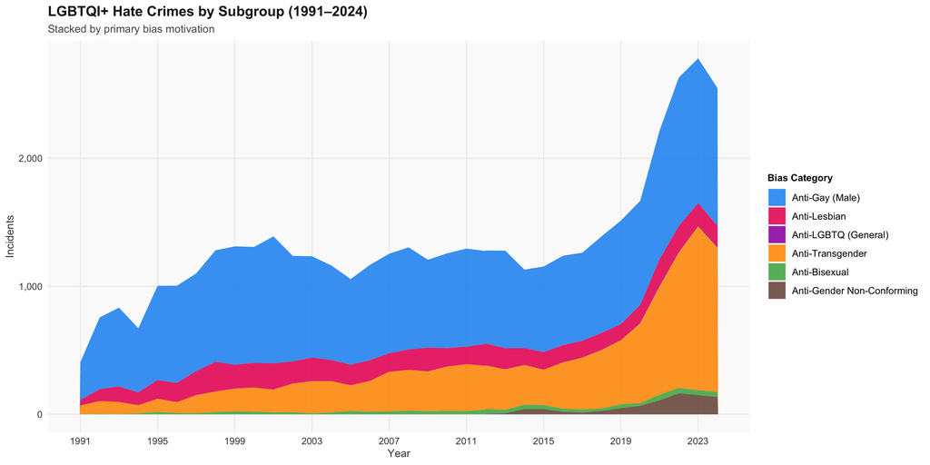

```r
cat_year <- full |>
  filter(BIAS_CATEGORY %in% names(BIAS_COLORS)) |>
  count(YEAR, BIAS_CATEGORY, name = "INCIDENTS") |>
  mutate(BIAS_CATEGORY = factor(BIAS_CATEGORY, levels = names(BIAS_COLORS)))

p02 <- ggplot(cat_year, aes(x = YEAR, y = INCIDENTS, fill = BIAS_CATEGORY)) +
  geom_area(position = "stack", alpha = 0.88) +
  scale_fill_manual(values = BIAS_COLORS, name = "Bias Category") +
  scale_x_continuous(breaks = seq(1991, 2024, 4)) +
  scale_y_continuous(labels = comma) +
  labs(title    = "LGBTQI+ Hate Crimes by Subgroup (1991–2024)",
       subtitle = "Stacked by primary bias motivation",
       x = "Year", y = "Incidents") +
  theme_hate() + theme(legend.position = "right")

p02
```

```r
save_chart(p02, "02_subgroup_trend.png", width = 12, height = 6)
```

## Chart 03 — Anti-Transgender & GNC Zoom (2013–2024)

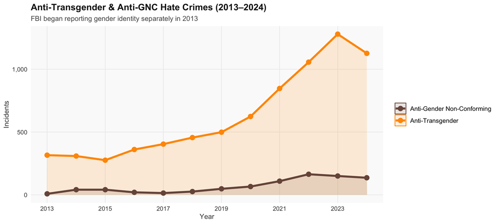

```r
trans_cats <- c("Anti-Transgender", "Anti-Gender Non-Conforming")
trans_data <- full |>
  filter(BIAS_CATEGORY %in% trans_cats, YEAR >= 2013) |>
  count(YEAR, BIAS_CATEGORY, name = "INCIDENTS")

p03 <- ggplot(trans_data, aes(x = YEAR, y = INCIDENTS,
                               colour = BIAS_CATEGORY, fill = BIAS_CATEGORY)) +
  geom_area(alpha = 0.15, position = "identity") +
  geom_line(linewidth = 1.4) +
  geom_point(size = 3) +
  scale_colour_manual(values = BIAS_COLORS[trans_cats], name = NULL) +
  scale_fill_manual(values   = BIAS_COLORS[trans_cats], name = NULL) +
  scale_x_continuous(breaks = seq(2013, 2024, 2)) +
  scale_y_continuous(labels = comma) +
  labs(title    = "Anti-Transgender & Anti-GNC Hate Crimes (2013–2024)",
       subtitle = "FBI began reporting gender identity separately in 2013",
       x = "Year", y = "Incidents") +
  theme_hate()

p03
```

```r
save_chart(p03, "03_transgender_trend.png", width = 9, height = 4.5)
```